# BRMS model for mean temperature

Justin Pomeranz

2024-03-28

# Abstract

This file summarizes the results of a Bayesian Hierarchichal model of stream temperatures in the TASR data set.

## Preliminaries

Load packages and data.

```r
library(tidyverse)
library(brms)
library(tidybayes)
```

The data includes the `source_info.csv` and the cleaned hourly tempertures produced by previously by Gordon Gianniny

```r
# source info
source_info <- read.csv(here::here("source_info.csv"))%>%
  rename(site = stream) #rename for merge

#Temperature data:
temp_clean <- read_csv(here::here("Temperature/cleaned_full_datasets/temps_hourly.csv"))
```

[output not shown]

```r
# merge and wrangle data
temp_clean <- left_join(temp_clean,
                        source_info)
temp_aug <- temp_clean %>%
  mutate(month = month(date1),
         year = year(date1))%>%
  select(temp_c, year, month, source, site) %>%
  filter(!is.na(temp_c),
         !is.na(source),
         !year == 2023,
         month == 8) %>%
  mutate(year_s = (year - mean(year)) / sd(year),
         temp_s = (temp_c - mean(temp_c)) / sd(temp_c))
```

`temp_aug` is a data object with data only from August and not including year 2023. `year_s` and `temp_s` are standardized as z-scores with a distribution of Normal(mean = 0, sd = 1).

### Plot the raw data

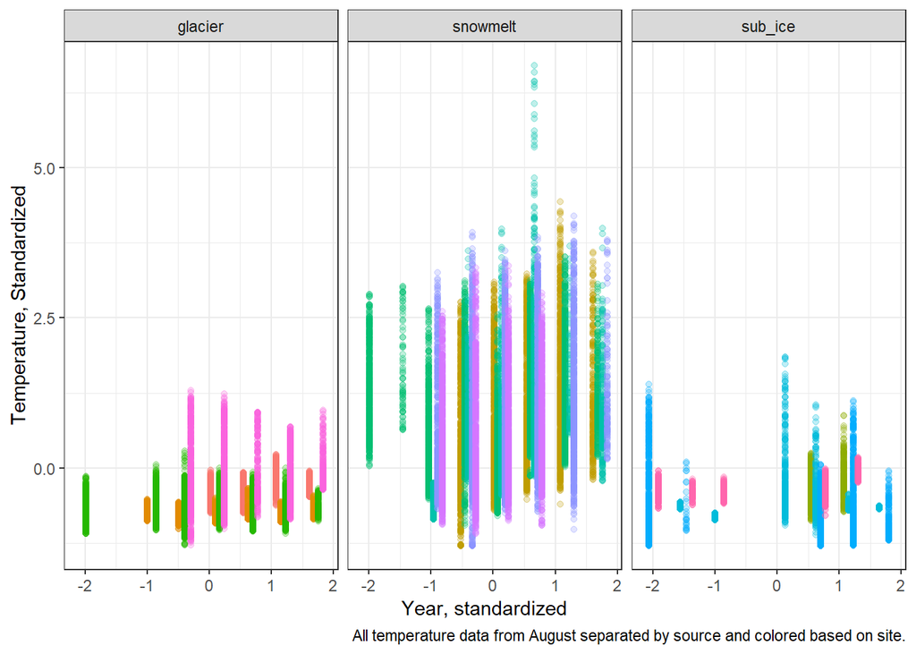

```r
temp_aug %>%
  ggplot(aes(x = year_s,
             y = temp_s,
             color = site)) +
  geom_point(alpha = 0.25,
             position =
               position_dodge(
                 width = 0.3
               )) +
  facet_wrap(~source) +
  theme_bw() +
  theme(legend.position = "none") +
  labs(x = "Year, standardized",
       y = "Temperature, Standardized",
       caption = "All temperature data from August separated by source and colored based on site.")
```

# Fit BRMS model

Note, the following code takes a while to run. It is pasted here for the record but is not run in this markdown file. Instead, I ran this model in a separate session and saved the model output and load that saved object in the next code chiunk immediately below.

```r
# use loosely informative priors to speed up model fitting
# prior distributions were simulated and plotted according to Wesner and Pomeranz 2021
my_prior <- c(prior(normal(0,0.5), class = b),
              prior(exponential(2), class = sd))

# fit a small, "dummy" model to compile STAN code
brm1 <- brm(temp_s ~ year_s * source +
              (1 |site) + (1|year_s),
            data = temp_aug,
            prior = my_prior,
            iter = 10,
            chains = 1)

# update the model with 2000 iterations on 4 independent chains.
brm1 <- update(brm1,
               chains = 4,
               cores = 4,
               iter = 2000)
```

### Load the saved model fit

```r
brm1 <- readRDS(here::here("Temperature/brms_models/fit_temp_yearXsource_rand_site_year.rds"))
brm1
```

```
##  Family: gaussian
##   Links: mu = identity; sigma = identity
## Formula: temp_s ~ year_s * source + (1 | site) + (1 | year_s)
##    Data: temp_aug (Number of observations: 40408)
##   Draws: 4 chains, each with iter = 2000; warmup = 1000; thin = 1;
##          total post-warmup draws = 4000
##
## Multilevel Hyperparameters:
## ~site (Number of levels: 13)
##               Estimate Est.Error l-95% CI u-95% CI
## sd(Intercept)     0.30      0.08     0.19     0.51
##               Rhat Bulk_ESS Tail_ESS
## sd(Intercept) 1.00     1656     1997
##
## ~year_s (Number of levels: 8)
##               Estimate Est.Error l-95% CI u-95% CI
## sd(Intercept)     0.22      0.08     0.12     0.43
##               Rhat Bulk_ESS Tail_ESS
## sd(Intercept) 1.00     1861     2113
##
## Regression Coefficients:
##                       Estimate Est.Error l-95% CI
## Intercept                -0.40      0.17    -0.72
## year_s                   -0.02      0.07    -0.15
## sourcesnowmelt            1.07      0.20     0.64
## sourcesub_ice            -0.15      0.19    -0.54
## year_s:sourcesnowmelt     0.28      0.01     0.26
## year_s:sourcesub_ice      0.01      0.01    -0.01
##                       u-95% CI Rhat Bulk_ESS
## Intercept                -0.04 1.00     2279
## year_s                    0.12 1.00     2361
## sourcesnowmelt            1.42 1.00     2214
## sourcesub_ice             0.23 1.00     2571
## year_s:sourcesnowmelt     0.30 1.00     4905
## year_s:sourcesub_ice      0.03 1.00     4606
##                       Tail_ESS
## Intercept                 2330
## year_s                    2087
## sourcesnowmelt            2522
## sourcesub_ice             2243
## year_s:sourcesnowmelt     2977
## year_s:sourcesub_ice      2786
##
## Further Distributional Parameters:
##       Estimate Est.Error l-95% CI u-95% CI Rhat
## sigma     0.68      0.00     0.67     0.68 1.00
##       Bulk_ESS Tail_ESS
## sigma     5325     2515
##
## Draws were sampled using sampling(NUTS). For each parameter, Bulk_ESS
## and Tail_ESS are effective sample size measures, and Rhat is the potential
## scale reduction factor on split chains (at convergence, Rhat = 1).
```

### Model Diagnostics

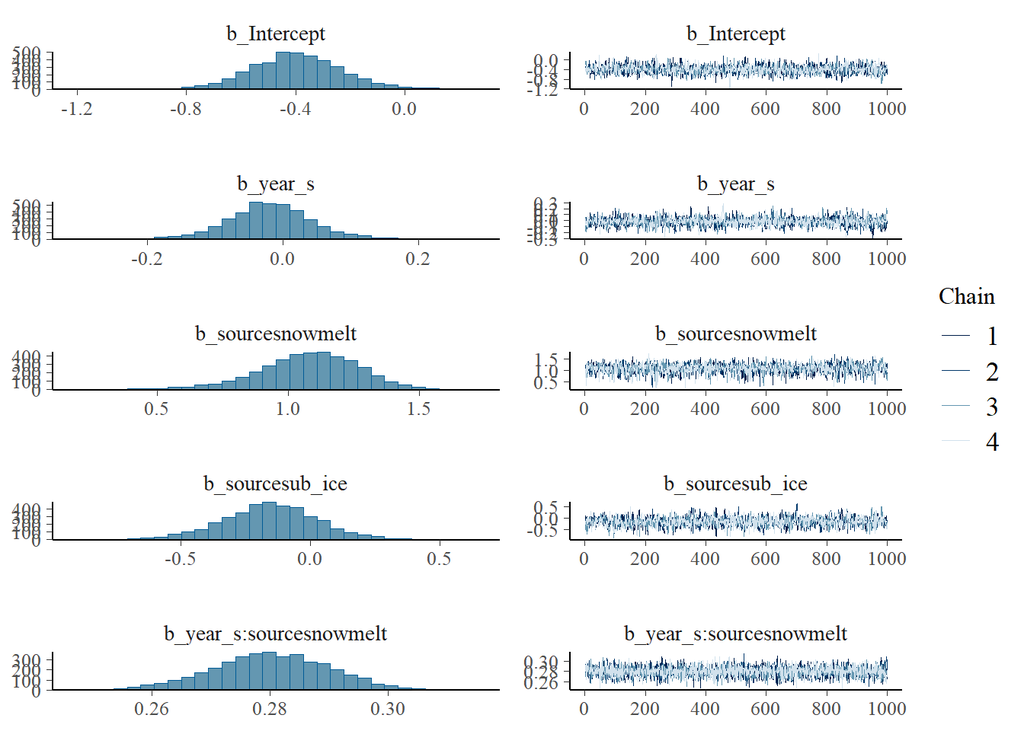

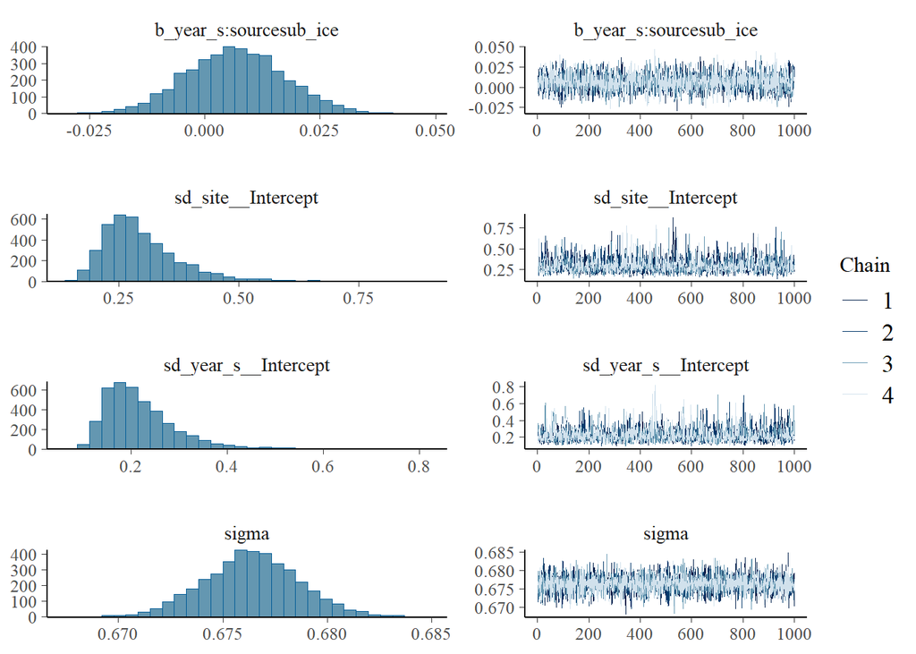

```r
plot(brm1, ask = FALSE)
```

**Note** Depending on the size of your screen you may not be able to see these very well but the take home message is that they look really good.

- Reasonable posterior distribution of coefficient estimates
- Chains look like “fuzzy caterpillars”
  - i.e., full coverage of the parameter space and well mixed chains.

### Posterior predictive checks

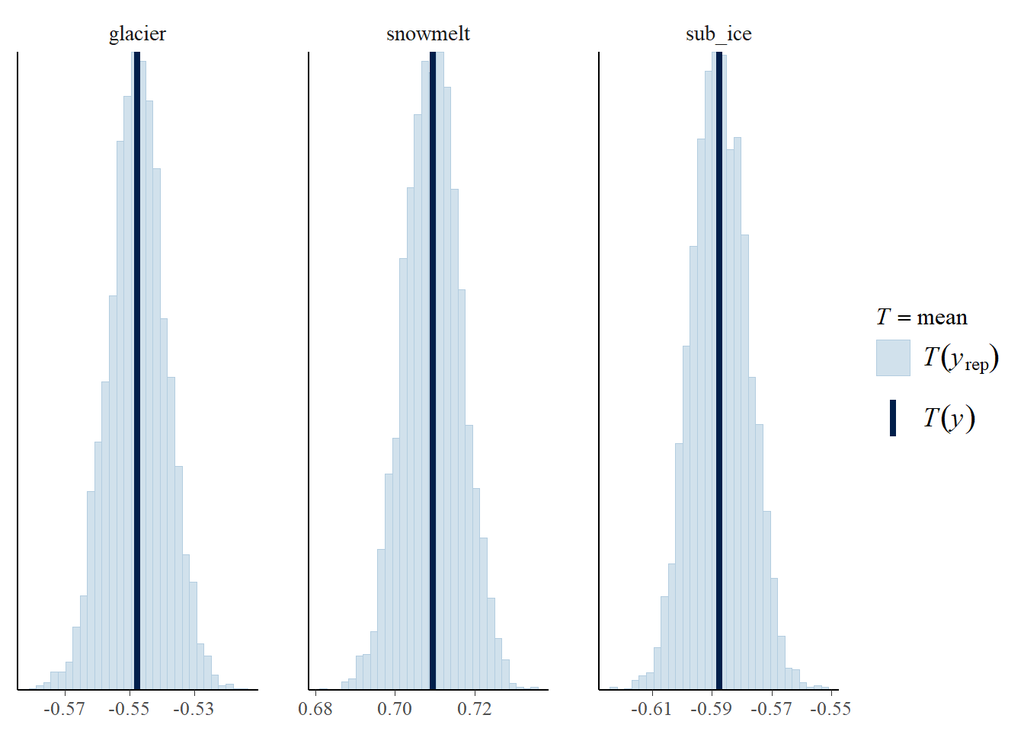

```r
pp_check(brm1,
         type = "stat_grouped",
         group = "source")
```

### Bayesian R-squared

```r
bayes_R2(object = brm1)
```

```
##     Estimate   Est.Error      Q2.5     Q97.5
## R2 0.5426152 0.002236663 0.5381956 0.5469593
```

## Conditional Effects

These plots show the over all effect of the main (fixed) predictors.

## Effect of source on intercept

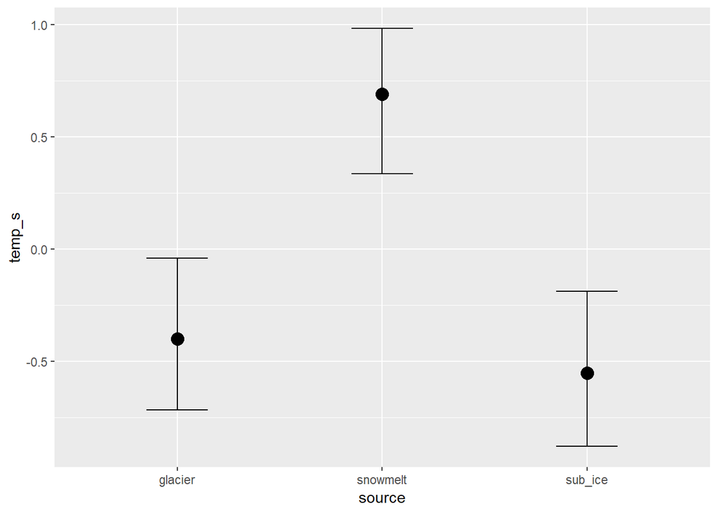

```r
conditional_effects(brm1, effects = "source")
```

This shows that Glacier and sub_ice streams have intercepts which are lower than the global intercept (and very similar to one another), while the snow melt stream has an intercept higher than the global intercept.

### Effect of year on Glacier streams

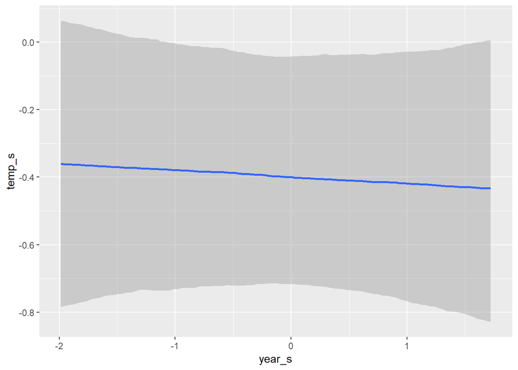

```r
c_plot <- conditional_effects(brm1)
plot(c_plot, plot = FALSE)[[1]]
```

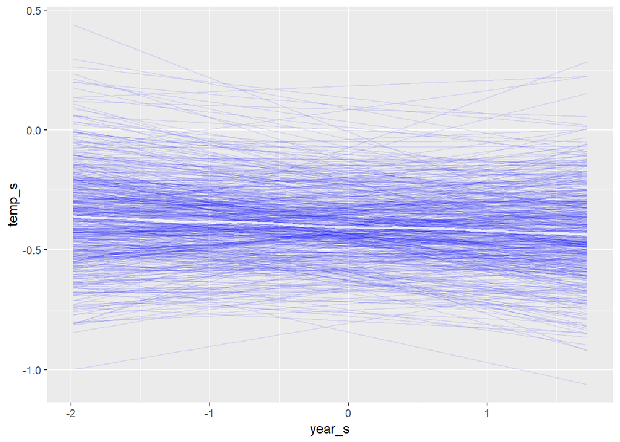

```r
c_plot_spag <- conditional_effects(brm1, spaghetti = TRUE, ndraws = 500)
plot(c_plot_spag, plot = FALSE)[[1]]
```

Spaghetti Plot. Each blue line is a regression estimate from the posterior distribution (note positive, flat, negative lines) and the white line is the overall mean effect of year on temperature.

```r
brm1 %>%
  spread_draws(b_year_s) %>%
  mutate(year_pos = b_year_s > 0) %>%
  summarize(mean(year_pos))
```

```
## # A tibble: 1 × 1
##   `mean(year_pos)`
##              <dbl>
## 1            0.369
```

## Effect of source on beta_year (Interaction)

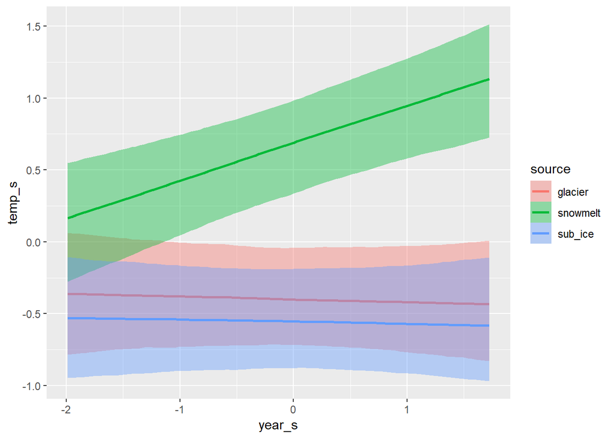

```r
conditional_effects(brm1, effects = "year_s:source")
```

This shows the interactive effect of source on year. The glacier and sub_ice streams maybe get slightly colder across time, but this is a minimal effect and stream temps are ~ equal.

The most striking result though is the increase in temperatures in snowmelt streams.

### Probability of other slopes

#### Sub_ice streams

```r
brm1 %>%
  spread_draws(b_Intercept,
               b_sourcesub_ice,
               b_year_s,
               `b_year_s:sourcesub_ice`) %>%
  rename(year_sub = `b_year_s:sourcesub_ice`) %>%
  mutate(sub = b_year_s + year_sub,
         sub_pos = sub > 0) %>%
  summarize(mean(sub_pos))
```

```
## # A tibble: 1 × 1
##   `mean(sub_pos)`
##             <dbl>
## 1           0.420
```

Sub ice streams have a 42% probability of being positive and 58% chance of being negative.

#### Snowmelt streams

```r
brm1 %>%
  spread_draws(b_year_s,
               `b_year_s:sourcesnowmelt`) %>%
  rename(year_snow = `b_year_s:sourcesnowmelt`) %>%
  mutate(snow = b_year_s + year_snow,
         snow_pos = snow > 0) %>%
  summarize(mean(snow_pos))
```

```
## # A tibble: 1 × 1
##   `mean(snow_pos)`
##              <dbl>
## 1            0.999
```

Snowmelt streams have a >99% chance of being positive.

### Interpretation

My first go at interpreting these results are that the glacier and sub_ice streams have a consistent source of snow/ice that is melting all year and keeping the temperatures low. It may even be that the increased melting across years results in deliviering more cold water to streams than “normal” and could be driving the slight decrease in stream temps.

My guess for the snowmelt streams are that later in the year (August) all the snow has melted (true or nah?) and the input of cold, recently melted ice water is lost and the streams heat up in the summer sun.

## One more plot for now

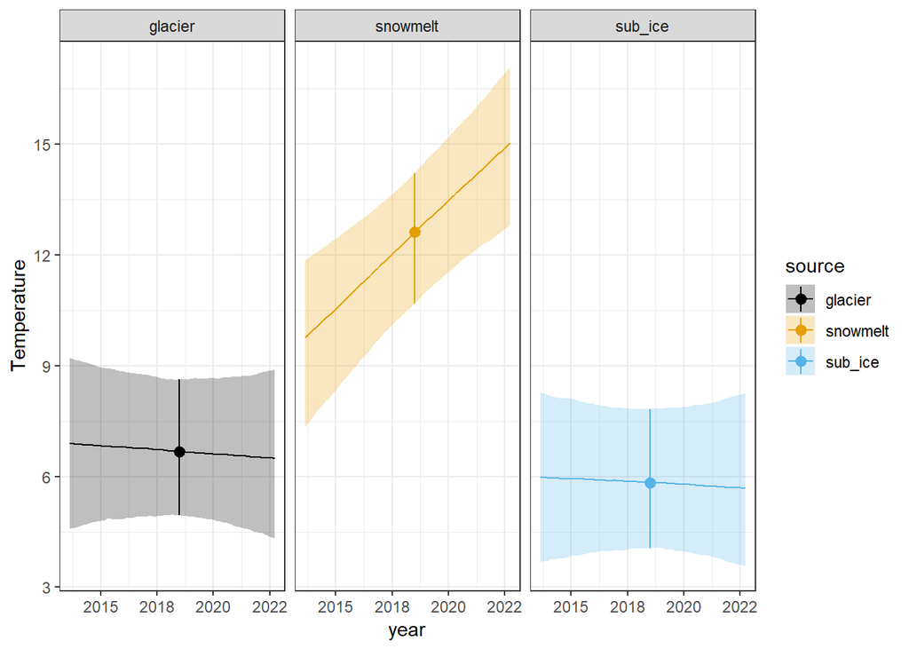

```r
# calculate mean and sd of original data
mean_year <- mean(unique(temp_aug$year))
sd_year <- sd(unique(temp_aug$year))
mean_temp <- mean(unique(temp_aug$temp_c))
sd_temp <- sd(unique(temp_aug$temp_c))

c_eff$`year_s:source` %>%
  as_tibble() %>%
  mutate(year = (year_s*sd_year)+mean_year,
         est_temp = (estimate__*sd_temp)+mean_temp,
         est_lo = (lower__*sd_temp)+mean_temp,
         est_high = (upper__*sd_temp)+mean_temp) %>%
  ggplot(aes(x = year,
             y = est_temp,
             color = source,
             fill = source)) +
  geom_ribbon(aes(ymin = est_lo,
                  ymax = est_high),
              alpha = 0.25,
              color = NA) +
  geom_line() +
  geom_pointrange(data = c_eff$source %>%
                    mutate(
                      year = (year_s*sd_year)+mean_year,
                      est_temp = (estimate__*sd_temp)+mean_temp,
                      est_lo = (lower__*sd_temp)+mean_temp,
                      est_high = (upper__*sd_temp)+mean_temp),
                  aes(x = year,
                      y = est_temp,
                      ymin = est_lo,
                      ymax = est_high)) +
  facet_grid(~source) +
  ggthemes::scale_fill_colorblind()+
  ggthemes::scale_color_colorblind() +
  theme_bw() +
  scale_x_continuous(labels = round) +
  labs(y = "Temperature")
```

This plot shows the overall effects and is rescaled to the original units. The middle line is the median of the posterior ditribution of the effect of year, and the shaded ribbons show the 95% credible intervals. The point and error bar is added to highlight the y-intercept at each site.

## Still to do

- rescale beta coefficients to be on original scale
  - i.e., right now it is estimated that for every 1 sd increase in year, there is a decrease in temperature of -0.018 sd’s for the Glacier streams
  - For every 1 sd increase in year, there is an increase of (-0.018 +0.28) sds in temperature for the snowmelt streams
  - I *think* it’s: $\beta_{temp:source} * (\sigma_{temp} / \sigma_{year})$
- Quantile regressions
  - This will be in lieu of the min/max_t regressions done previously.